Skip to content

# Week03 CSS

```python
## Cascading Style Sheets
```

## Cascading Style Sheets

### CSS Syntax

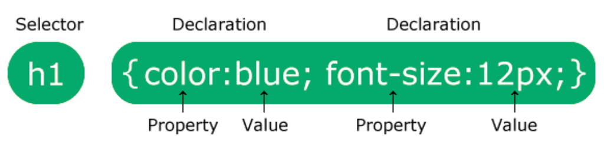

- Selection: HTML element you want to style
- Declaration: includes a property name and a value, separated by a colon; one of more declarations separated by semicolons

### Ways to use CSS

- Inline: using the style attribute inside HTML elements
- Internal: using the style element in the head sectio
- External: using a link element to an external CSS file

#### Inline CSS

`<h1 style="color:blue;font-size: 30px">Introduction</h1>`

#### Internal CSS

- Internal CSS is used to define a style for a single html page.
- An internal CSS is defined in the `<head>` section of an HTML page, within a `<style>` element

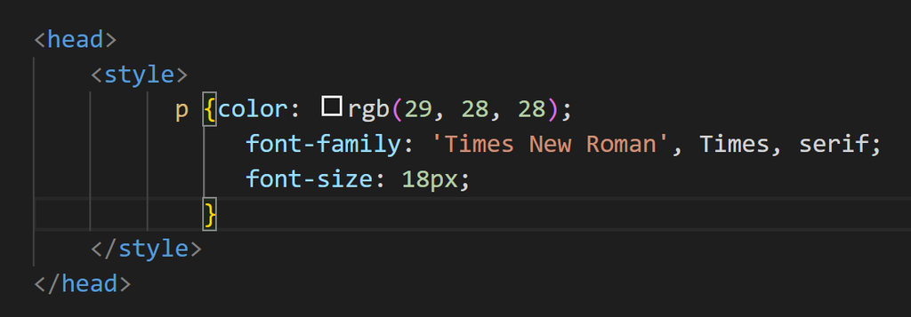

### Internal CSS: Selector

For an internal CSS, we have severl ways to specify the selector.

#### element name selector

`p {text-align: center; color: red;}`

### Exercise 1: Add Interval CSS based on element

1. Add internal css for `<p>`
2. Add internal css for `<h1>` or other heading

#### id selector

- `id` is used to specify a unique id for an HTML element and must be unique within the HTML document.
- The `id` of an element is better to be unique within a page
- You can have multiple element with same `id` but functions will only return the first matching element

### Exercise 2: Add Interval CSS based on id

Step 1: add the id for a element

`<p id="intro">Hello World!</p>`

Step 2: write a hash (#) then followed by an id name and define the CSS within curly braces {}

`<style>#intro{text-align: center;color: red;}</style>`

#### class selector

- Class is used to specify a class for an HTML element
- Multiple HTML elements can share the same class

`.center { text-align: center; color: red; }`

In the below example, only `p` element with class = `"center"` will be red and center-aligned

`p.center { text-align: center;color: red;}`

### Exercise 3: Add Internal CSS based on class

1. Add internal css for elements with same class 2. Add internal css for specific elements with specific class

### Cascading order for Inline, Internal and External style sheets

The priority is highest to lowest from 1 to 3

1. Inline style
2. Internal style
3. External style

So, an inline style will override external and internal styles.

### Exercise 4: Test priority of inline and internal style

1. Create inline style and internal style for same element to see the difference

### Exercise 5: Beautify navigation links

#### Attributes for li tag

- list-style: none;
- display: inline-block;
- line-height: 2;
- margin-right: 50px;

#### Attributes for a tag

- font-size: 30px;
- color: rgb(104, 104, 215);

#### Attribute for hover effect in a tag

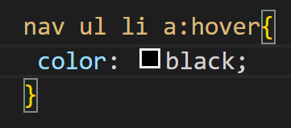

#### Attributes for nav tag

- justify-content: flex-end;
- display: flex;

### Margin, border and padding

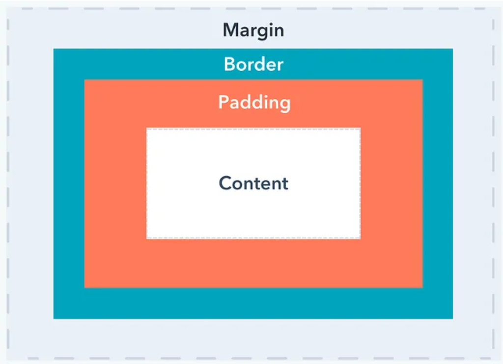

#### Margin property

- margin: 25px 50px 75px 100px
- padding: 25px 50px 75px 100px
  - top margin is 25 px
  - right margin is 50 px
  - bottom margin is 75 px
  - left margin is 100px
- [border](https://www.w3schools.com/css/css_border.asp)

### Exercise 6: Beautify Intro section (margin, padding, border)

- set up your div into left or right
  - float: left;
- set up margin, or padding, or border for your different section
  - margin-left: 200px;
  - margin-top: 100px;
  - margin-right: 200px;

### Exercise 7: Beautify li section (margin, padding, border)

- Add class in `ul` first then you can specify the attribute for all `li` under `ul`
  - font-size: 20px;
  - font-family: 'Times New Roman', Times, serif;
  - line-height: 25px;

### Exercise 8: Beautify Figure (margin, padding, border)

- Figure is special because it contain two parts, one is img and one is Figureshare
- Modify the image size

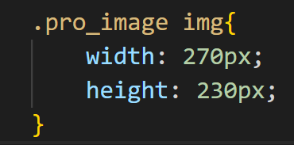

- Create three figures
- Place three Figures in a line horizontally
  - display: flex;
  - justify-content: center;
  - gap: 250px;

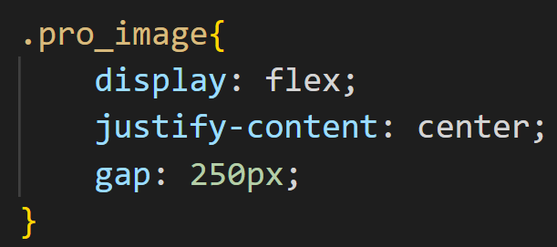

### Exercise 9: Beautify Footer

9.1 Add the extra information to to footer

- like address, copyright

9.2 Add Contact Me Section

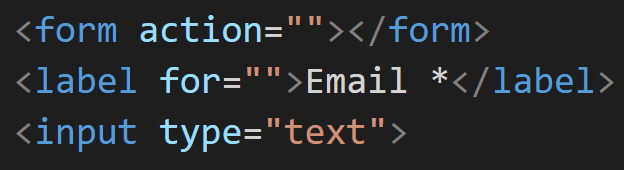

9.2 Set up margin, padding or border to each element

- You can make the border as solid to help you adjust the margin, padding or border

2025-02-22 2025-02-22